# Lista 3 resolução

Henrique de Souza Passos

2025-02-05

# Limpeza do Ambiente

```r
rm(list = ls())
```

# Carregamento de Pacotes

```r
library(knitr)
library(haven)
library(texreg)
library(plm)
library (AER)
library(rdrobust)
library(rddensity)
library(quantreg)
library(data.table)
```

# 1. Programa de distribuição de material

```r
banco <- read_dta("~/mestrado/infcausal/Lista_3/banco_diff_diff.dta")
```

1.a. O impacto do programa foi positivo mas não muito alto, o coeficiente da variável $grupo_tratado·d.2007$ foi de 8.2 na proficiência em português e de 8.1 na proficiência e matemática, o que sugere um aumento baixo dado que a proficiência média das escolas não tratadas em 2006 (dada pelo intercepto) é de 182.53 para português e 187.8 para matemática. Além disso o $R²$ de amas regressões também é baixo (0.01 e 0.09) mostrando que os modelos têm baixa capacidade explicativa.

```r
banco$grupo_tratado_2007 <- banco$grupo_tratado * banco$ano_2007

eq_profic_port <- profic_port ~ grupo_tratado_2007 + grupo_tratado + ano_2007
eq_profic_mat <- profic_mat ~ grupo_tratado_2007 + grupo_tratado + ano_2007

reg_proficport <- lm(eq_profic_port, data = banco)
reg_proficmat <- lm(eq_profic_mat, data = banco)


summary((reg_proficport))
```

```
##
## Call:
## lm(formula = eq_profic_port, data = banco)
##
## Residuals:
##     Min      1Q  Median      3Q     Max
## -63.492 -11.592  -0.947  10.796  73.276
##
## Coefficients:
##                    Estimate Std. Error t value Pr(>|t|)
## (Intercept)        182.5334     0.2749 664.067  < 2e-16 ***
## grupo_tratado_2007   8.2054     1.7282   4.748 2.09e-06 ***
## grupo_tratado        1.9045     1.2221   1.558    0.119
## ano_2007            -2.8918     0.3887  -7.439 1.13e-13 ***
## ---
## Signif. codes:  0 '***' 0.001 '**' 0.01 '*' 0.05 '.' 0.1 ' ' 1
##
## Residual standard error: 16.33 on 7428 degrees of freedom
## Multiple R-squared:  0.01507,    Adjusted R-squared:  0.01467
## F-statistic: 37.88 on 3 and 7428 DF,  p-value: < 2.2e-16
```

```r
screenreg(reg_proficport, digits = 4, custom.model.names = c("proficiência português"))
```

```
##
## ==========================================
##                     proficiência português
## ------------------------------------------
## (Intercept)          182.5334 ***
##                       (0.2749)
## grupo_tratado_2007     8.2054 ***
##                       (1.7282)
## grupo_tratado          1.9045
##                       (1.2221)
## ano_2007              -2.8918 ***
##                       (0.3887)
## ------------------------------------------
## R^2                    0.0151
## Adj. R^2               0.0147
## Num. obs.           7432
## ==========================================
## *** p < 0.001; ** p < 0.01; * p < 0.05
```

```r
summary((reg_proficmat))
```

```
##
## Call:
## lm(formula = eq_profic_mat, data = banco)
##
## Residuals:
##     Min      1Q  Median      3Q     Max
## -60.454 -12.245  -1.505  10.887 110.465
##
## Coefficients:
##                    Estimate Std. Error t value Pr(>|t|)
## (Intercept)        187.8043     0.2929 641.091  < 2e-16 ***
## grupo_tratado_2007   8.0958     1.8419   4.395 1.12e-05 ***
## grupo_tratado        4.3749     1.3024   3.359 0.000786 ***
## ano_2007            10.1388     0.4143  24.473  < 2e-16 ***
## ---
## Signif. codes:  0 '***' 0.001 '**' 0.01 '*' 0.05 '.' 0.1 ' ' 1
##
## Residual standard error: 17.4 on 7428 degrees of freedom
## Multiple R-squared:  0.09567,    Adjusted R-squared:  0.0953
## F-statistic: 261.9 on 3 and 7428 DF,  p-value: < 2.2e-16
```

```r
screenreg(reg_proficmat, digits = 4, custom.model.names = c("proficiência matemática"))
```

```
##
## ===========================================
##                     proficiência matemática
## -------------------------------------------
## (Intercept)          187.8043 ***
##                       (0.2929)
## grupo_tratado_2007     8.0958 ***
##                       (1.8419)
## grupo_tratado          4.3749 ***
##                       (1.3024)
## ano_2007              10.1388 ***
##                       (0.4143)
## -------------------------------------------
## R^2                    0.0957
## Adj. R^2               0.0953
## Num. obs.           7432
## ===========================================
## *** p < 0.001; ** p < 0.01; * p < 0.05
```

1.c. Estimar esse modelo por efeitos fixos pode reuzir o viés causado por diferenças estruturais entre escolas. Como as escolas podem ter características fixas que influenciam a proficiência, como qualidade dos professores ou infraestrutura, o efeito fixo controla essas diferenças, focando apenas no impacto das variáveis explicativas ao longo do tempo dentro da mesma escola. Os resultados foram parecidos com o modelo OLS mostrando um resultado positivo do programa, o coeficiente do tratamento foi de 10.11 para a proficiência em português e de 12.47 para matemática.

```r
eq_profic_port_fe <- profic_port ~ tratamento + ano_2007
eq_profic_mat_fe <- profic_mat ~ tratamento + ano_2007

reg_proficport_fe <- plm(eq_profic_port_fe, data = banco, type = "within")
reg_proficmat_fe <- lm(eq_profic_mat_fe, data = banco, type = "within")
summary((reg_proficport_fe))
```

```
## Oneway (individual) effect Within Model
##
## Call:
## plm(formula = eq_profic_port_fe, data = banco, type = "within")
##
## Unbalanced Panel: n = 2, T = 3716-3716, N = 7432
##
## Residuals:
##      Min.   1st Qu.    Median   3rd Qu.      Max.
## -63.58831 -11.59053  -0.92947  10.80726  73.17937
##
## Coefficients:
##            Estimate Std. Error t-value  Pr(>|t|)
## tratamento  10.1100     1.2222  8.2721 < 2.2e-16 ***
## ---
## Signif. codes:  0 '***' 0.001 '**' 0.01 '*' 0.05 '.' 0.1 ' ' 1
##
## Total Sum of Squares:    1998900
## Residual Sum of Squares: 1980600
## R-Squared:      0.0091269
## Adj. R-Squared: 0.0088602
## F-statistic: 68.4285 on 1 and 7429 DF, p-value: < 2.22e-16
```

```r
screenreg(reg_proficport_fe, digits = 4, custom.model.names = c("proficiência português"))
```

```
##
## ==================================
##             proficiência português
## ----------------------------------
## tratamento    10.1100 ***
##               (1.2222)
## ----------------------------------
## R^2            0.0091
## Adj. R^2       0.0089
## Num. obs.   7432
## ==================================
## *** p < 0.001; ** p < 0.01; * p < 0.05
```

```r
summary((reg_proficmat_fe))
```

```
##
## Call:
## lm(formula = eq_profic_mat_fe, data = banco, type = "within")
##
## Residuals:
##     Min      1Q  Median      3Q     Max
## -60.454 -12.169  -1.525  10.949 110.465
##
## Coefficients:
##             Estimate Std. Error t value Pr(>|t|)
## (Intercept) 188.0256     0.2856 658.271   <2e-16 ***
## tratamento   12.4707     1.3033   9.569   <2e-16 ***
## ano_2007      9.9175     0.4093  24.231   <2e-16 ***
## ---
## Signif. codes:  0 '***' 0.001 '**' 0.01 '*' 0.05 '.' 0.1 ' ' 1
##
## Residual standard error: 17.41 on 7429 degrees of freedom
## Multiple R-squared:  0.09429,    Adjusted R-squared:  0.09405
## F-statistic: 386.7 on 2 and 7429 DF,  p-value: < 2.2e-16
```

```r
screenreg(reg_proficmat_fe, digits = 4, custom.model.names = c("proficiência matemática"))
```

```
##
## ====================================
##              proficiência matemática
## ------------------------------------
## (Intercept)   188.0256 ***
##                (0.2856)
## tratamento     12.4707 ***
##                (1.3033)
## ano_2007        9.9175 ***
##                (0.4093)
## ------------------------------------
## R^2             0.0943
## Adj. R^2        0.0941
## Num. obs.    7432
## ====================================
## *** p < 0.001; ** p < 0.01; * p < 0.05
```

1.d. O modelo de primeiras diferenças mede as variações temporais, portanto ele não faz um controle para características fixas das escolas como no modelo de efeitos fixos. Então, estimar pelas diferenças pode ser menos eficiente se houver características não observáveis que afetam simultaneamente as variáveis ao longo do tempo, por isso o modelo de efeitos fixos seria mais recomendado nesse caso.

1.e. Um coeficiente $\hat{\beta}_0=10$ indica que a proficiência média de uma escola não tratada em 2005 é de 10 pontos. O erro-padrão de 3 (não muito grande em relação ao coeficiente) sugere que essa estimativa é estatisticamente confiável.

#2.

```r
gileade <- read_dta("~/mestrado/infcausal/Lista_3/LATECovid19simulation.dta")
```

2.a.

```r
source("~/mestrado/infcausal/Aulas 2024/sources/tabulate.R")
tabulate(gileade,col=c("campaign","lockdown"),col.percentage = TRUE)
```

```
##                      | lockdown
##             campaign |                0                1  |            Total
## ----------------------------------------------------------------------------
##                    0 |             1898              851  |             2749
##                      |        0.4903126        0.5023613  |        0.4939802
##                    1 |             1973              843  |             2816
##                      |        0.5096874        0.4976387  |        0.5060198
## ----------------------------------------------------------------------------
##                Total |             3871             1694  |             5565
##                      |                1                1  |                1
```

2.b. No primeiro estágio vemos pelo intercepto que municípios sem campanha de conscientização nem lockdown tinham, em média, um nível inicial de distanciamento social de 16%. Municípios onde a campanha foi implementada tiveram, em média, 18,5% a mais de distanciamento social e o lockdown aumentou o distanciamento social em 63.7%. O p-valor de ambas variáveis foi baixo mostrando que os sefeitos forma significativos. O $R^2$ ajustado de 0.9287 indica que os instrumentos são fortes e a estatística F de 36.225 não dá indício de instrumentos fracos.

```r
first_stage <- lm(social_distancing ~ campaign + lockdown, data = gileade)
summary(first_stage)
```

```
##
## Call:
## lm(formula = social_distancing ~ campaign + lockdown, data = gileade)
##
## Residuals:
##       Min        1Q    Median        3Q       Max
## -0.298720 -0.056785  0.007252  0.053159  0.284563
##
## Coefficients:
##             Estimate Std. Error t value Pr(>|t|)
## (Intercept) 0.160177   0.001791   89.44   <2e-16 ***
## campaign    0.184771   0.002276   81.18   <2e-16 ***
## lockdown    0.636852   0.002473  257.52   <2e-16 ***
## ---
## Signif. codes:  0 '***' 0.001 '**' 0.01 '*' 0.05 '.' 0.1 ' ' 1
##
## Residual standard error: 0.08489 on 5562 degrees of freedom
## Multiple R-squared:  0.9287, Adjusted R-squared:  0.9287
## F-statistic: 3.623e+04 on 2 and 5562 DF,  p-value: < 2.2e-16
```

```r
modelo_2sls <- ivreg(covid_fatality_pm ~ social_distancing | campaign + lockdown , data = gileade)
summary(modelo_2sls)
```

```
##
## Call:
## ivreg(formula = covid_fatality_pm ~ social_distancing | campaign +
##     lockdown, data = gileade)
##
## Residuals:
##       Min        1Q    Median        3Q       Max
## -1810.250  -353.856    -5.736   351.915  2014.351
##
## Coefficients:
##                   Estimate Std. Error t value Pr(>|t|)
## (Intercept)        2121.50      12.28  172.78   <2e-16 ***
## social_distancing  -356.66      22.64  -15.75   <2e-16 ***
## ---
## Signif. codes:  0 '***' 0.001 '**' 0.01 '*' 0.05 '.' 0.1 ' ' 1
##
## Residual standard error: 517.3 on 5563 degrees of freedom
## Multiple R-Squared: 0.03703, Adjusted R-squared: 0.03686
## Wald test: 248.1 on 1 and 5563 DF,  p-value: < 2.2e-16
```

```r
residuos <- residuals(modelo_2sls)
sargan_test <- lm(residuos ~ campaign + lockdown, data = gileade)

sargan_stat <- summary(sargan_test)$r.squared * nrow(gileade)

p_value <- 1 - pchisq(sargan_stat, df = 2 - 1) # df = (número de instrumentos - variáveis instrumentadas)

cat("Estatística do Teste de Sargan:", sargan_stat, "\n")
```

```
## Estatística do Teste de Sargan: 42.9223
```

```r
cat("P-valor:", p_value, "\n")
```

```
## P-valor: 5.695766e-11
```

2.c. O teste de Sargan indicom existe um problema de endogeneidade, isso significa que pelo menos um dos instrumentos (ou ambos) está correlacionado com o erro, tornando-os inválidos. O viés dependerá da correlação entre os instrumentos e o erro do modelo, se os instrumentos estiverem positivamente correlacionados com a variável omitida (como pobreza), o coeficiente de social_distancing pode estar subestimado. Se os instrumentos estiverem negativamente correlacionados com a variável omitida, o coeficiente pode estar superestimado.

2.d. Assumindo que tivéssemos os dados de pobreza dos municípios, manteríamos as variáveis Campaingn e Lockdown que influenciam o distanciamento social e adicionaríamos um indicador de pobreza do município nos dois estágios, pois pobreza pode ajudar a explicar tanto o distanciamento social quanto a taxa de mortalidade.

[Pobreza] -> [Covid Fatality PM] v ^ [Social Distancing] -> [Covid Fatality PM] ^ [Campaign/Lockdown]

#3.

```r
voucher <- read_dta("~/mestrado/infcausal/Lista_3/Training_voucher.dta")
```

3.b. O gráfico mostra um salto na probabilidade das pessoas elegíveis ao voucher participarem do treinamento em relação às pessoas não elegíveis.

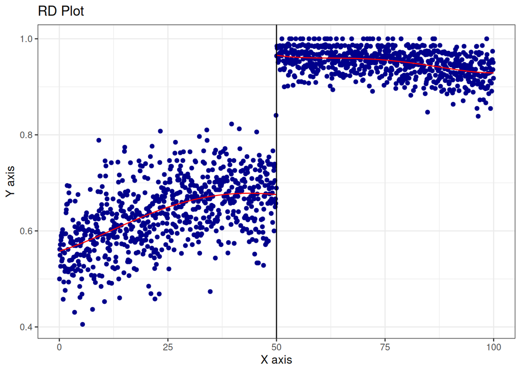

```r
rdplot(voucher$Training_program, voucher$poverty_index, c = 50)
```

3.c. O gráfico mostra que pessoas que tinham um poverty_index>50 tiveram, em média, um aumento de renda maior e esse aumento foi mais significativo quanto mais perto o índice estiver de 50.

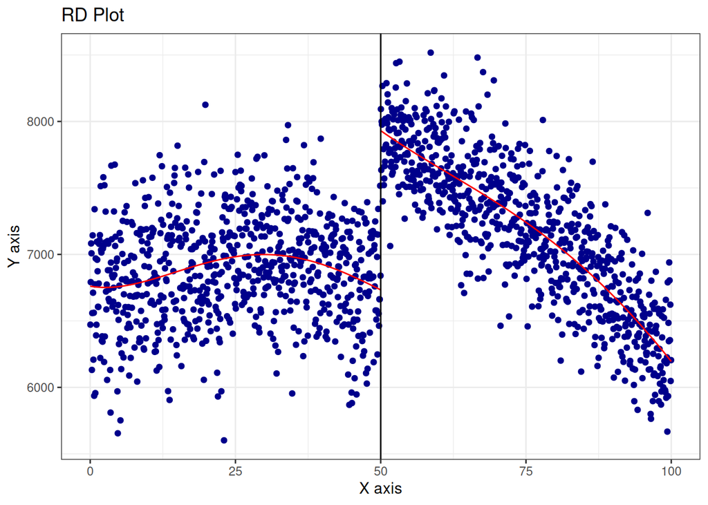

```r
voucher$income_diff <- voucher$labor_income - voucher$labor_income_pre
rdplot(voucher$income_diff, voucher$poverty_index, c = 50)
```

3.d. O coeficiente indica que há um aumento médio de R$ 1.142,20 na variação da renda para aqueles que estão logo acima do threshold de pobreza em comparação com aqueles logo abaixo. A estatística z tem valor elevado e o p-valor é baixo indicando que o tratamento tem um impacto significativo na renda. Os valores do teste robusto seguem a mesma tendência, reforçando a validade da estimativa.

```r
rdd_result <- rdrobust(voucher$income_diff, voucher$poverty_index, c = 50)
print(summary(rdd_result))
```

```
## Sharp RD estimates using local polynomial regression.
##
## Number of Obs.               100000
## BW type                       mserd
## Kernel                   Triangular
## VCE method                       NN
##
## Number of Obs.                49878        50122
## Eff. Number of Obs.           13772        13786
## Order est. (p)                    1            1
## Order bias  (q)                   2            2
## BW est. (h)                  13.746       13.746
## BW bias (b)                  21.423       21.423
## rho (h/b)                     0.642        0.642
## Unique Obs.                   49799        49953
##
## =============================================================================
##         Method     Coef. Std. Err.         z     P>|z|      [ 95% C.I. ]
## =============================================================================
##   Conventional  1142.198    72.811    15.687     0.000   [999.491 , 1284.905]
##         Robust         -         -    13.006     0.000   [957.432 , 1297.204]
## =============================================================================
## NULL
```

3.e. Analisando as regressões descontínuas com polinômios de 1 a 5, os testes mostram que a estatística z mais alta é para o polinômio de primeira ordem o que indica que o efeito é mais significativo nesse caso.

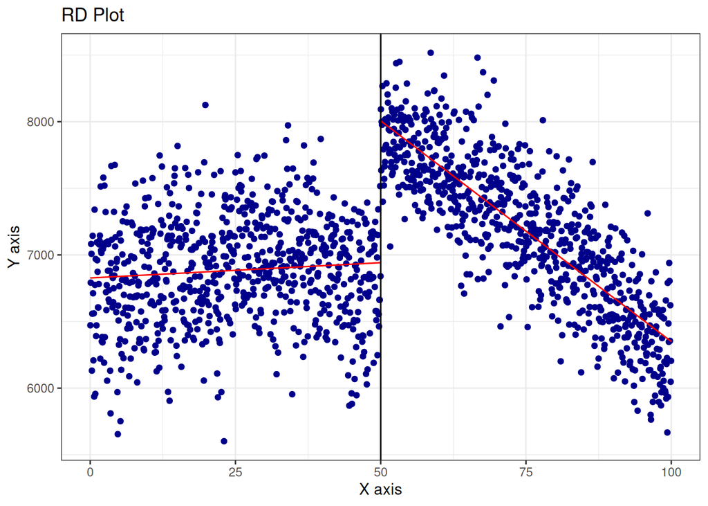

```r
rdplot(voucher$income_diff, voucher$poverty_index, p=1, c = 50)
```

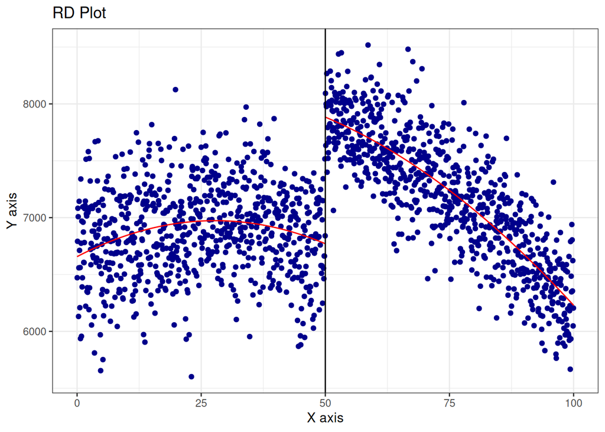

```r
rdplot(voucher$income_diff, voucher$poverty_index, p=2, c = 50)
```

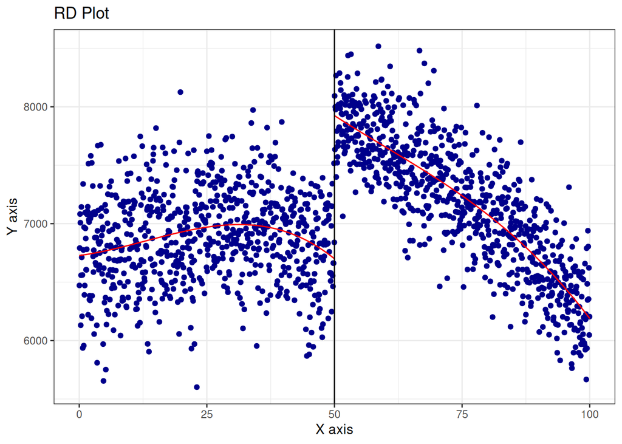

```r
rdplot(voucher$income_diff, voucher$poverty_index, p=3, c = 50)
```

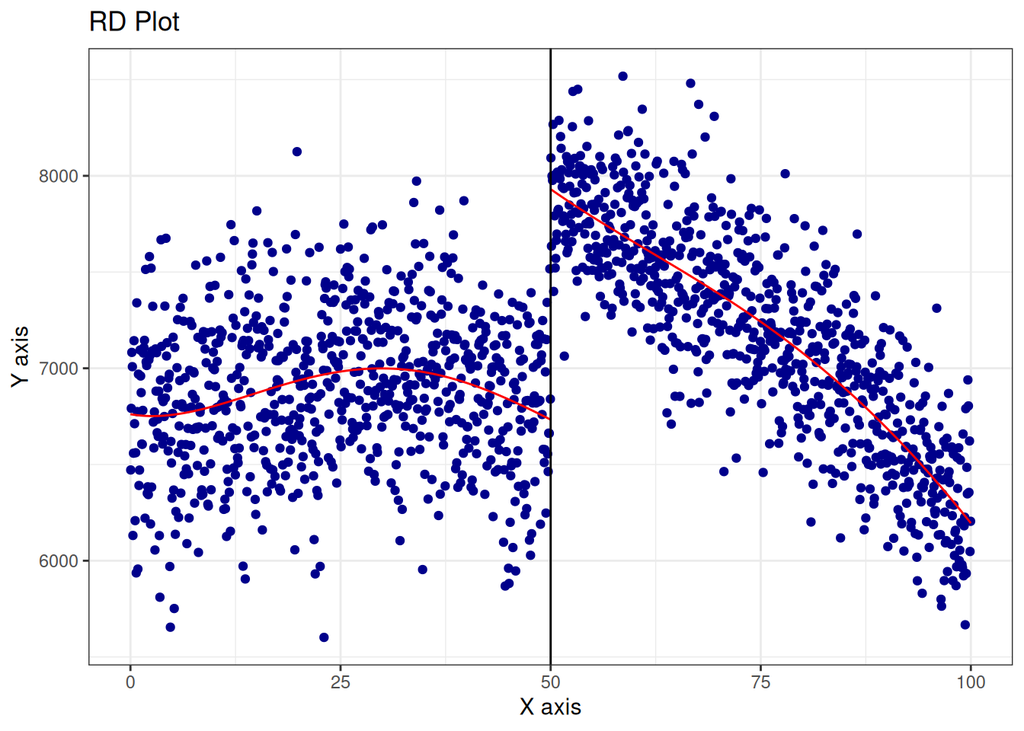

```r
rdplot(voucher$income_diff, voucher$poverty_index, p=4, c = 50)
```

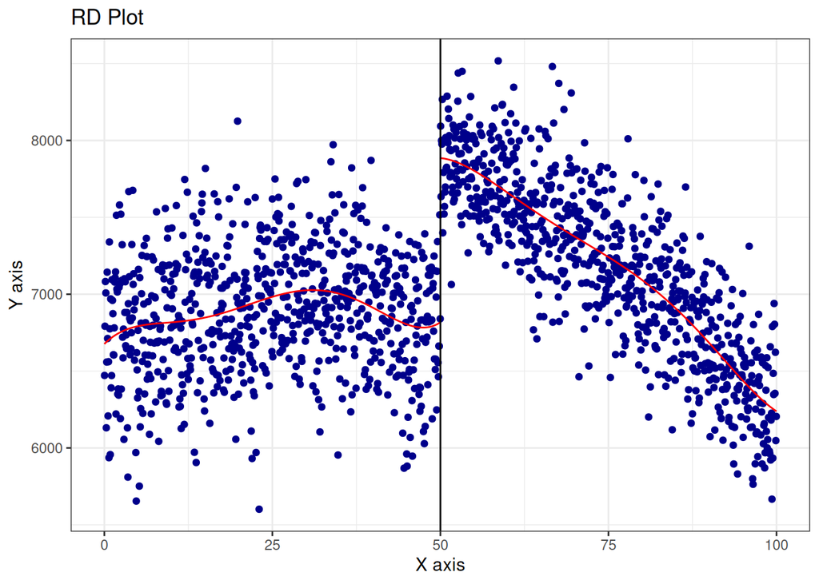

```r
rdplot(voucher$income_diff, voucher$poverty_index, p=5, c = 50)
```

```r
print(summary(rdrobust(voucher$income_diff, voucher$poverty_index, p=1, c = 50)))
```

```
## Sharp RD estimates using local polynomial regression.
##
## Number of Obs.               100000
## BW type                       mserd
## Kernel                   Triangular
## VCE method                       NN
##
## Number of Obs.                49878        50122
## Eff. Number of Obs.           13772        13786
## Order est. (p)                    1            1
## Order bias  (q)                   2            2
## BW est. (h)                  13.746       13.746
## BW bias (b)                  21.423       21.423
## rho (h/b)                     0.642        0.642
## Unique Obs.                   49799        49953
##
## =============================================================================
##         Method     Coef. Std. Err.         z     P>|z|      [ 95% C.I. ]
## =============================================================================
##   Conventional  1142.198    72.811    15.687     0.000   [999.491 , 1284.905]
##         Robust         -         -    13.006     0.000   [957.432 , 1297.204]
## =============================================================================
## NULL
```

```r
print(summary(rdrobust(voucher$income_diff, voucher$poverty_index, p=2, c = 50)))
```

```
## Sharp RD estimates using local polynomial regression.
##
## Number of Obs.               100000
## BW type                       mserd
## Kernel                   Triangular
## VCE method                       NN
##
## Number of Obs.                49878        50122
## Eff. Number of Obs.           13369        13377
## Order est. (p)                    2            2
## Order bias  (q)                   3            3
## BW est. (h)                  13.335       13.335
## BW bias (b)                  21.009       21.009
## rho (h/b)                     0.635        0.635
## Unique Obs.                   49799        49953
##
## =============================================================================
##         Method     Coef. Std. Err.         z     P>|z|      [ 95% C.I. ]
## =============================================================================
##   Conventional  1028.785   108.318     9.498     0.000   [816.485 , 1241.085]
##         Robust         -         -     8.419     0.000   [760.774 , 1222.505]
## =============================================================================
## NULL
```

```r
print(summary(rdrobust(voucher$income_diff, voucher$poverty_index, p=3, c = 50)))
```

```
## Sharp RD estimates using local polynomial regression.
##
## Number of Obs.               100000
## BW type                       mserd
## Kernel                   Triangular
## VCE method                       NN
##
## Number of Obs.                49878        50122
## Eff. Number of Obs.           18395        18648
## Order est. (p)                    3            3
## Order bias  (q)                   4            4
## BW est. (h)                  18.520       18.520
## BW bias (b)                  25.536       25.536
## rho (h/b)                     0.725        0.725
## Unique Obs.                   49799        49953
##
## =============================================================================
##         Method     Coef. Std. Err.         z     P>|z|      [ 95% C.I. ]
## =============================================================================
##   Conventional   974.094   120.831     8.062     0.000   [737.269 , 1210.919]
##         Robust         -         -     7.235     0.000   [685.714 , 1195.294]
## =============================================================================
## NULL
```

```r
print(summary(rdrobust(voucher$income_diff, voucher$poverty_index, p=4, c = 50)))
```

```
## Sharp RD estimates using local polynomial regression.
##
## Number of Obs.               100000
## BW type                       mserd
## Kernel                   Triangular
## VCE method                       NN
##
## Number of Obs.                49878        50122
## Eff. Number of Obs.           24929        25068
## Order est. (p)                    4            4
## Order bias  (q)                   5            5
## BW est. (h)                  25.000       25.000
## BW bias (b)                  31.450       31.450
## rho (h/b)                     0.795        0.795
## Unique Obs.                   49799        49953
##
## =============================================================================
##         Method     Coef. Std. Err.         z     P>|z|      [ 95% C.I. ]
## =============================================================================
##   Conventional   935.979   128.762     7.269     0.000   [683.610 , 1188.348]
##         Robust         -         -     6.588     0.000   [638.526 , 1179.333]
## =============================================================================
## NULL
```

```r
print(summary(rdrobust(voucher$income_diff, voucher$poverty_index, p=5, c = 50)))
```

```
## Sharp RD estimates using local polynomial regression.
##
## Number of Obs.               100000
## BW type                       mserd
## Kernel                   Triangular
## VCE method                       NN
##
## Number of Obs.                49878        50122
## Eff. Number of Obs.           26476        26641
## Order est. (p)                    5            5
## Order bias  (q)                   6            6
## BW est. (h)                  26.581       26.581
## BW bias (b)                  30.980       30.980
## rho (h/b)                     0.858        0.858
## Unique Obs.                   49799        49953
##
## =============================================================================
##         Method     Coef. Std. Err.         z     P>|z|      [ 95% C.I. ]
## =============================================================================
##   Conventional   937.041   148.575     6.307     0.000   [645.840 , 1228.243]
##         Robust         -         -     5.923     0.000   [632.017 , 1257.230]
## =============================================================================
## NULL
```

#4.

```r
jtrain <- read_dta("~/mestrado/infcausal/Lista_3/jtrain3.dta")
lista3ex4 <- read.csv(paste("~/mestrado/infcausal/Lista_3/lista3ex4itc.csv", sep=""),header=TRUE, sep=",", dec=".")
```

```r
reg_re78 <- rq(re78 ~ train + re75 + educ + age, tau = c(0.1, 0.25, 0.5, 0.75, 0.9), data = jtrain, na.action = na.exclude , method="br")
res_re78 <- summary(reg_re78, se="boot")
print(res_re78)
```

```
##
## Call: rq(formula = re78 ~ train + re75 + educ + age, tau = c(0.1, 0.25,
##     0.5, 0.75, 0.9), data = jtrain, na.action = na.exclude, method = "br")
##
## tau: [1] 0.1
##
## Coefficients:
##             Value    Std. Error t value  Pr(>|t|)
## (Intercept) -1.95049  1.56110   -1.24943  0.21162
## train        0.28899  0.65164    0.44349  0.65745
## re75         0.62645  0.04860   12.89009  0.00000
## educ         0.13697  0.09325    1.46894  0.14197
## age         -0.00709  0.01526   -0.46468  0.64220
##
## Call: rq(formula = re78 ~ train + re75 + educ + age, tau = c(0.1, 0.25,
##     0.5, 0.75, 0.9), data = jtrain, na.action = na.exclude, method = "br")
##
## tau: [1] 0.25
##
## Coefficients:
##             Value    Std. Error t value  Pr(>|t|)
## (Intercept) -0.91654  0.71368   -1.28424  0.19917
## train       -0.20818  0.33490   -0.62162  0.53425
## re75         0.89361  0.01189   75.14520  0.00000
## educ         0.19893  0.05405    3.68021  0.00024
## age         -0.03261  0.01288   -2.53071  0.01144
##
## Call: rq(formula = re78 ~ train + re75 + educ + age, tau = c(0.1, 0.25,
##     0.5, 0.75, 0.9), data = jtrain, na.action = na.exclude, method = "br")
##
## tau: [1] 0.5
##
## Coefficients:
##             Value     Std. Error t value   Pr(>|t|)
## (Intercept)   4.48246   0.70905    6.32176   0.00000
## train        -0.69508   0.66860   -1.03962   0.29861
## re75          0.96296   0.01599   60.22813   0.00000
## educ          0.16009   0.05263    3.04202   0.00237
## age          -0.11083   0.01045  -10.60246   0.00000
##
```

[output cut: 10 more lines]

```
## educ         0.46584  0.09862    4.72375  0.00000
## age         -0.11647  0.02318   -5.02509  0.00000
##
## Call: rq(formula = re78 ~ train + re75 + educ + age, tau = c(0.1, 0.25,
##     0.5, 0.75, 0.9), data = jtrain, na.action = na.exclude, method = "br")
##
## tau: [1] 0.9
##
## Coefficients:
##             Value    Std. Error t value  Pr(>|t|)
## (Intercept)  5.14714  3.29379    1.56268  0.11825
## train        0.56947  1.86173    0.30588  0.75972
## re75         0.88605  0.04767   18.58545  0.00000
## educ         0.90578  0.20310    4.45973  0.00001
## age         -0.03775  0.05260   -0.71767  0.47302
```

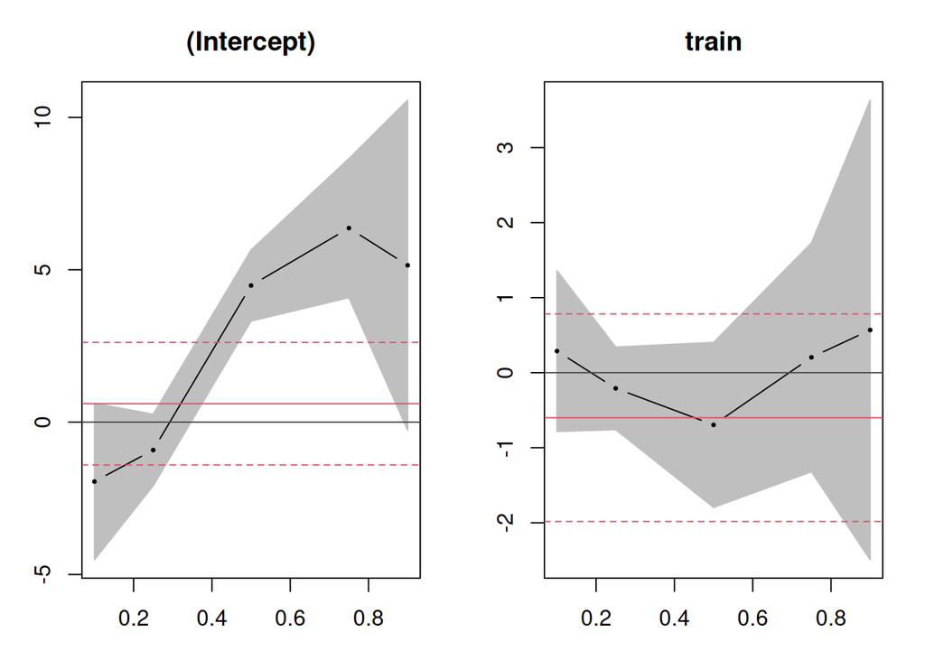

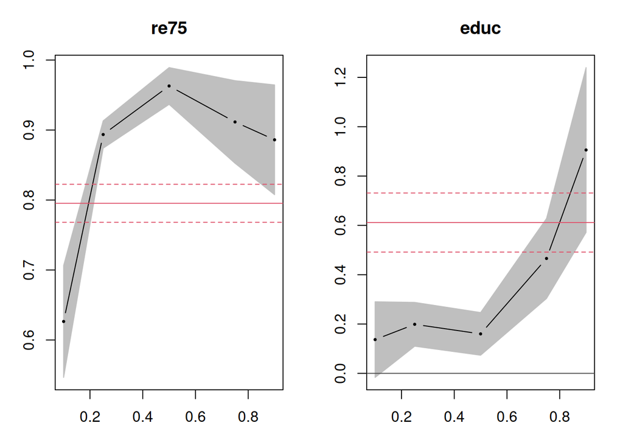

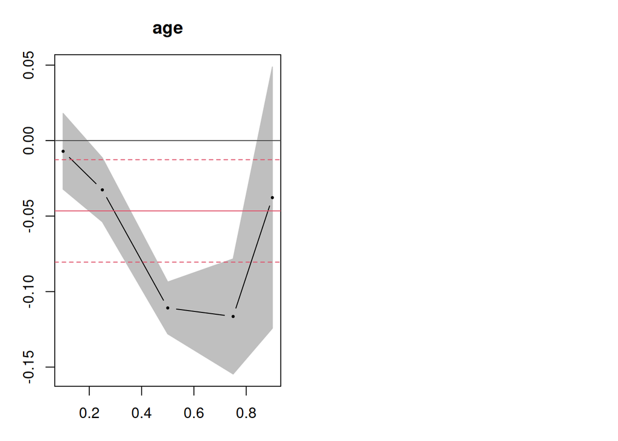

```r
plot(res_re78, mfrow = c(1,2))
```

4.c. Nesse caso, o efeito do tratamento é positivo para todos os quantis, no entanto, o p-valor do coeficiente é estatisticamente significativo a partir do quantil 0.5. O efeito é crescente em relação aos quantis, pessoas de renda mais alta tem maior crescimento na renda quando fazem o treinamento.

```r
df0 <- subset(lista3ex4, treat_itemC == 0)
df1 <- subset(lista3ex4, treat_itemC == 1)

m0 <- glm(Z_voucher ~ re78_c + re75 + educ + age, data = df0, family = binomial(link = "probit"))
lista3ex4$hat_z0 <- predict(m0, newdata = lista3ex4, type = "response")

m1 <- glm(Z_voucher ~ re78_c + re75 + educ + age, data = df1, family = binomial(link = "probit"))
lista3ex4$hat_z1 <- predict(m1, newdata = lista3ex4, type = "response")

m_all <- glm(Z_voucher ~ re78_c + re75 + educ + age, data = lista3ex4, family = binomial(link = "probit"))
lista3ex4$hat_p <- predict(m_all, newdata = lista3ex4, type = "response")

lista3ex4$kappa <- 1 - lista3ex4$treat_itemC * (1 - lista3ex4$hat_z1) / (1 - lista3ex4$hat_p) -  (1 - lista3ex4$treat_itemC) * (lista3ex4$hat_z0) / lista3ex4$hat_p

lista3ex4$kappa<- ifelse(lista3ex4$kappa<0,0,lista3ex4$kappa)


result.kappaaai<-rq(re78_c ~ treat_itemC + re75 + educ + age, data=lista3ex4, tau=c(0.1, 0.25, 0.5, 0.75, 0.9), na.action = na.exclude, method="br", weights = c(kappa))
result.kappaaai.fit<-summary(result.kappaaai , se="boot")
print(list(result.kappaaai.fit))
```

```
## [[1]]
##
## Call: rq(formula = re78_c ~ treat_itemC + re75 + educ + age, tau = c(0.1,
##     0.25, 0.5, 0.75, 0.9), data = lista3ex4, weights = c(kappa),
##     na.action = na.exclude, method = "br")
##
## tau: [1] 0.1
##
## Coefficients:
##             Value    Std. Error t value  Pr(>|t|)
## (Intercept) -1.92761  1.01204   -1.90468  0.05693
## treat_itemC  0.07486  0.38999    0.19195  0.84779
## re75         0.83819  0.02203   38.04161  0.00000
## educ         0.33686  0.08746    3.85164  0.00012
## age         -0.04679  0.01777   -2.63267  0.00852
##
## Call: rq(formula = re78_c ~ treat_itemC + re75 + educ + age, tau = c(0.1,
##     0.25, 0.5, 0.75, 0.9), data = lista3ex4, weights = c(kappa),
##     na.action = na.exclude, method = "br")
##
## tau: [1] 0.25
##
## Coefficients:
##             Value    Std. Error t value  Pr(>|t|)
## (Intercept)  0.44454  1.60215    0.27746  0.78145
## treat_itemC  0.38714  0.40289    0.96091  0.33668
## re75         0.88438  0.02035   43.45850  0.00000
## educ         0.47317  0.09320    5.07662  0.00000
## age         -0.06551  0.02363   -2.77276  0.00560
##
## Call: rq(formula = re78_c ~ treat_itemC + re75 + educ + age, tau = c(0.1,
##     0.25, 0.5, 0.75, 0.9), data = lista3ex4, weights = c(kappa),
##     na.action = na.exclude, method = "br")
##
## tau: [1] 0.5
##
## Coefficients:
##             Value    Std. Error t value  Pr(>|t|)
## (Intercept)  6.61901  1.19964    5.51748  0.00000
## treat_itemC  0.88265  0.43414    2.03311  0.04214
```

[output cut: 16 more lines]

```
## age         -0.08173  0.02561   -3.19068  0.00144
##
## Call: rq(formula = re78_c ~ treat_itemC + re75 + educ + age, tau = c(0.1,
##     0.25, 0.5, 0.75, 0.9), data = lista3ex4, weights = c(kappa),
##     na.action = na.exclude, method = "br")
##
## tau: [1] 0.9
##
## Coefficients:
##             Value    Std. Error t value  Pr(>|t|)
## (Intercept) 14.54078  2.14375    6.78286  0.00000
## treat_itemC  1.71473  0.48870    3.50874  0.00046
## re75         0.82798  0.02781   29.77074  0.00000
## educ         0.57464  0.13003    4.41923  0.00001
## age         -0.05436  0.03236   -1.68003  0.09307
```

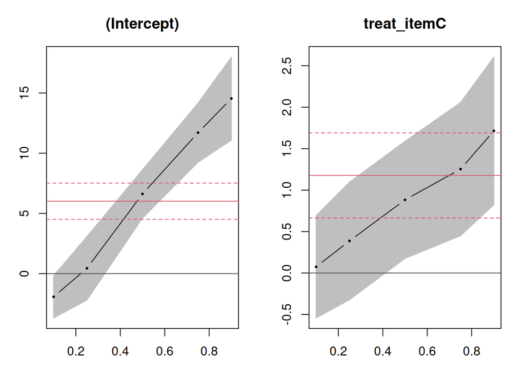

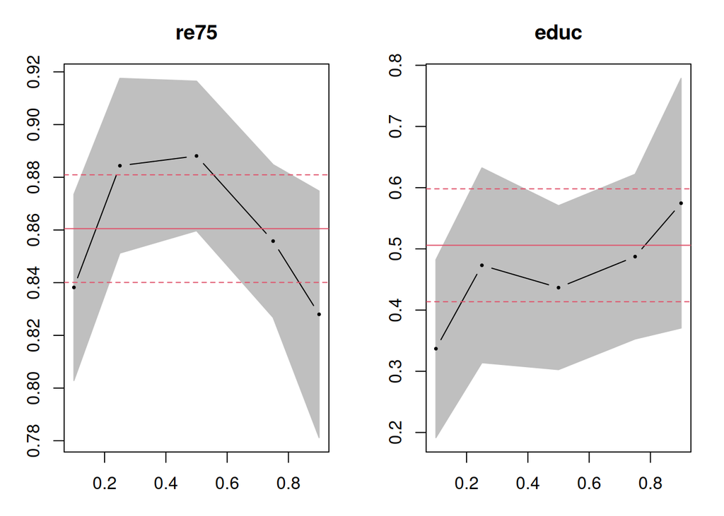

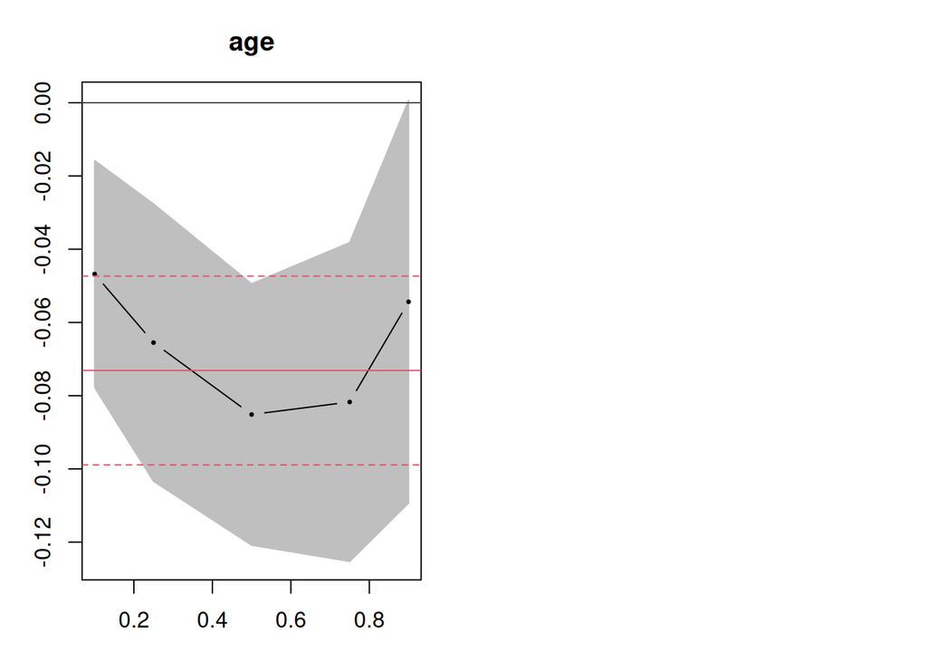

```r
fit1.result.kappaaai <- summary(rq(re78_c ~ treat_itemC + re75 + educ + age, data=lista3ex4, tau=c(0.1, 0.25, 0.5, 0.75, 0.9), na.action = na.exclude, weights=c(kappa)), se = "boot")
plot(fit1.result.kappaaai, mfrow = c(1,2))
```